# CAPM

Mike

2023-03-13

# Modelo CAPM

Vamos a estimar el modelo CAMP para un activo

Información del activo: BIMBO (BIMBOA.MX) Informacion del mercado: IPC (^MXX) Información de la tasa de libre de riesgo: Cetes a un año (Canvas)

La información de cetes la voy a obtener del Banco de México y la información de la empresa y el IPC lo descargaremos directo de Yahoo Finance.

```r
rm (list=ls())
setwd("~/Documents")

library(quantmod)
library(PerformanceAnalytics)
library(tidyverse)
library(readxl)
library(lmtest)
library(lubridate)

datos <- new.env()

ids <- c("BIMBOA.MX", "^MXX")

getSymbols(ids, from="2018-01-01", to=today(),
           env=datos)
```

```
## [1] "BIMBOA.MX" "^MXX"
```

Una vez descargados los activos, voy a manipular los datos para generar un data.frame que contenga toda la información necesaria para estimar la línea característica del activo Bimbo.

Recordemos que la linea característica es:

$$R_j - R_f = \alpha + \beta (R_M - R_f)
+ u$$

```r
precio_a <- datos[["BIMBOA.MX"]][,6]
precio_a_mes <- to.monthly(precio_a)[,4]
precio_ipc <- datos[["MXX"]][,6]
precio_ipc_mes <- to.monthly(precio_ipc)[,4]

activo_rendm <- monthlyReturn(precio_a_mes)[-1,]
ipc_rendm <- monthlyReturn(precio_ipc_mes)[-1,]

names(activo_rendm) <- "bimbo"
names(ipc_rendm) <- "IPC"

activos <- cbind(activo_rendm, ipc_rendm)

activos <- as.data.frame(activos)

#fechas <- as.data.frame(ipc_rendm[,0])
#fechas <- row.names(fechas)

activos <- activos %>%
  mutate(t=seq(1,62, by=1))
```

Análisis gráfico

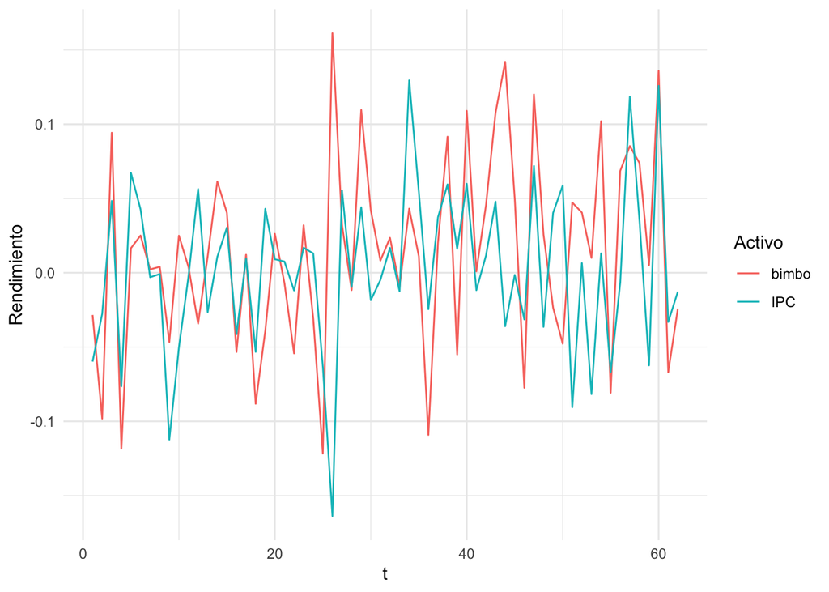

```r
activos %>%
  gather(key="Activo", value="Rendimiento", -t) %>%
  ggplot(aes(x=t, y=Rendimiento))+
  geom_line(aes(color=Activo))+
  theme_minimal()
```

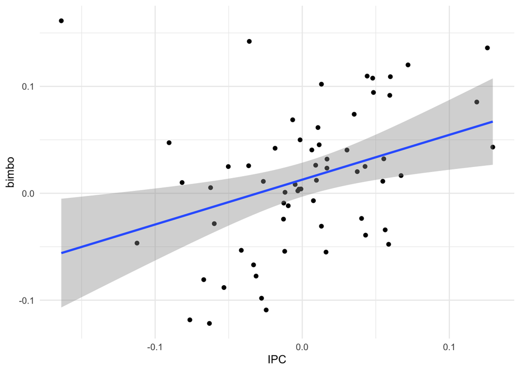

```r
activos %>%
  ggplot(aes(x=IPC, y=bimbo))+
  geom_point()+
  theme_minimal()+
  geom_smooth(method = lm)
```

Nos falta la tasa libre de riesgo. Vamos a importar esta tasa cete

Eliminamos los objetos inecesarios

```r
rm(activo_rendm, datos, ids, ipc_rendm, precio_a, precio_a_mes, precio_ipc, precio_ipc_mes)
```

Vamos importa la tasa cetes

```r
cetes <- read_excel("tasacete.xlsx")

cetes <- cetes %>%
  filter(SF43945!="N/E") %>%
  mutate(SF43945=(as.numeric(SF43945)/100)/12,
         year=year(Fecha)) %>%
  filter(year>=2018)

Rf <- as.xts(cetes$SF43945, order.by = cetes$Fecha)
Rf <- to.monthly(Rf)[-1,4]

activos <- cbind(activos, Rf)
names(activos) <- c("bimbo", "IPC", "t", "Rf")
```

Generamos las variables dependiente e independientes.

La variable dependiente es $Rej$ tal que:

$$Rej=R_j - R_f$$
Y la variable independiente:

$$Rem=R_M-R_f$$
Donde: $R_j$ es el rendimiento del activo (Bimbo), $R_f$ es la tasa libre de riesgo (Cetes), y $R_M$ es la rendimiento de mercado (IPC).

```r
activos <- activos %>%
  mutate(rej=bimbo-Rf,
         rem=IPC-Rf)
```

Con esto, podemos estimar la línea característica del activo Bimbo

```r
capm <- lm(rej ~ rem, data=activos)
```

Analizamos los resultados

```r
resultados <- summary(capm)

resultados
```

```
##
## Call:
## lm(formula = rej ~ rem, data = activos)
##
## Residuals:
##      Min       1Q   Median       3Q      Max
## -0.10999 -0.04508 -0.00537  0.03701  0.21819
##
## Coefficients:
##             Estimate Std. Error t value Pr(>|t|)
## (Intercept) 0.009167   0.007960   1.152  0.25409
## rem         0.422424   0.144973   2.914  0.00501 **
## ---
## Signif. codes:  0 '***' 0.001 '**' 0.01 '*' 0.05 '.' 0.1 ' ' 1
##
## Residual standard error: 0.0625 on 60 degrees of freedom
## Multiple R-squared:  0.124,  Adjusted R-squared:  0.1094
## F-statistic:  8.49 on 1 and 60 DF,  p-value: 0.00501
```

Un coeficiente estadísticamente significativo, quiere decir que es estadísticamente diferente de cero. i.e. rechaza la hipótesis nula de que el coeficiente estimado es igual a cero.

Necesitamos realizar la siguiente prueba de hipótesis:

$H_O: \beta=1$ vs. $H_a: \beta \neq 1$

Construimos un estadístico de prueba:

$$t_p= (\beta-Ho) / SE(\beta)$$

```r
tp <- (resultados$coefficients[2,1]-1)/resultados$coefficients[2,2]

tp
```

```
## [1] -3.98403
```

Calculamos el valor-p, es necesario calcular prob(t<=tp)+prob(t>=tp):

```r
(1-pt(abs(tp), resultados$df[2]))*2
```

```
## [1] 0.0001859478
```

Este valor-p es menor al nivel de significancia del 1%, y por lo tanto también al 5% y al 10%. i.e, existe evidencia suficiente para rechazar la hipótesis nula de que $\beta$ es igual uno El beta es menor a uno, por lo tanto bimbo no es volátil.

Analicemos alfa, en este caso alfa resulto no significativo, es decir, este coeficiente es estadísticamente igual a cero.

Finalmente, analizamos el riesgo sistemico y no sistemico

El $R^2$, es el porcentaje del riesgo sistemático

```r
resultados$r.squared*100
```

```
## [1] 12.39637
```

En este modelo mi $R^2$ es de 12.39%, el riesgo de este activo es 12% sistemático, y por lo tanto, el riesgo no riesgo no sistemático es de

```r
100-resultados$r.squared*100
```

```
## [1] 87.60363
```

El riesgo no sistemático representa el 87% del riesgo de mi activo (o portafolio). Sí el riesgo no sistemático representa más del 60% se recomienda diversificar el portafolio.

Finalmente, cuantificamos el riesgo:

```r
RT=((resultados$sigma^2)/(1-resultados$r.squared))*100

RT
```

```
## [1] 0.445935
```

Mi riesgo total (volatilidad del activo) es de 0.44%

El riesgo no sistemático:

```r
RNS <- (resultados$sigma^2)*100

RNS
```

```
## [1] 0.3906552
```

Por lo tanto

El riesgo sistemático

```r
RS=RT-RNS

RS
```

```
## [1] 0.05527976
```